# Mid Trimester

# Question 2

In a digestion trial carried out with 6 shorthorn steers, each animal received one of 6 rations in 6 successive periods following a Latin square design. The coefficients of digestibility of nitrogen for each steer and period are as follows:

| steer | period 1 | period 2 | period 3 | period 4 | period 5 | period 6 |
| --- | --- | --- | --- | --- | --- | --- |
| 1 | 61.1 (B) | 69.3 (D) | 67.6 (C) | 61.9 (F) | 58.8 (A) | 65.2 (E) |
| 2 | 56.9 (A) | 59.1 (F) | 64.0 (D) | 61.0 (C) | 65.7 (E) | 56.6 (B) |
| 3 | 66.5 (C) | 62.2 (A) | 61.1 (B) | 66.2 (E) | 62.0 (F) | 62.2 (D) |
| 4 | 66.7 (E) | 67.4 (B) | 65.1 (F) | 65.1 (D) | 69.6 (C) | 52.7 (A) |
| 5 | 67.8 (D) | 64.7 (C) | 63.6 (E) | 53.2 (A) | 61.7 (B) | 62.0 (F) |
| 6 | 71.4 (F) | 67.5 (E) | 55.8 (A) | 63.2 (B) | 68.0 (D) | 62.9 (C) |

The rations consist of: - A: Hay alone - B: Various mixtures of hay and barley (Rations B, C, D, E, F)

## 1. Assess the effects of different rations on the digestibility of nitrogen. Include an analysis of variance (ANOVA) to test the significance of the ration effects, period effects, and steer effects.

### Load the data

```r
q2_data = data.frame(Steer = rep(1:6, each = 6),
                     Period = rep(1:6, times = 6),
                     Treatment = c('B', 'D', 'C', 'F', 'A', 'E',
                                   'A', 'F', 'D', 'C', 'E', 'B',
                                   'C', 'A', 'B', 'E', 'F', 'D',
                                   'E', 'B', 'F', 'D', 'C', 'A',
                                   'D', 'C', 'E', 'A', 'B', 'F',
                                   'F', 'E', 'A', 'B', 'D', 'C'),
                     Digestion = c(61.1, 69.3, 67.6, 61.9, 58.8,65.2,
                                   56.9, 59.1, 64.0, 61.0, 65.7, 56.6,
                                   66.5, 62.2, 61.1, 66.2, 62.0, 62.2,
                                   66.7, 67.4, 65.1, 65.1, 69.6, 52.7,
                                   67.8, 64.7, 63.6, 53.2, 61.7, 62.0,
                                   71.4, 67.5, 55.8, 63.2, 68.0, 62.9))
q2_data
```

```
##    Steer Period Treatment Digestion
## 1      1      1         B      61.1
## 2      1      2         D      69.3
## 3      1      3         C      67.6
## 4      1      4         F      61.9
## 5      1      5         A      58.8
## 6      1      6         E      65.2
## 7      2      1         A      56.9
## 8      2      2         F      59.1
## 9      2      3         D      64.0
## 10     2      4         C      61.0
## 11     2      5         E      65.7
## 12     2      6         B      56.6
## 13     3      1         C      66.5
## 14     3      2         A      62.2
```

[output cut: 22 more lines]

### Anova

```r
q2_data$Treatment = as.factor(q2_data$Treatment)
q2_data$Steer = factor(q2_data$Steer)
q2_data$Period = factor(q2_data$Period)
str(q2_data)
```

```
## 'data.frame':    36 obs. of  4 variables:
##  $ Steer    : Factor w/ 6 levels "1","2","3","4",..: 1 1 1 1 1 1 2 2 2 2 ...
##  $ Period   : Factor w/ 6 levels "1","2","3","4",..: 1 2 3 4 5 6 1 2 3 4 ...
##  $ Treatment: Factor w/ 6 levels "A","B","C","D",..: 2 4 3 6 1 5 1 6 4 3 ...
##  $ Digestion: num  61.1 69.3 67.6 61.9 58.8 65.2 56.9 59.1 64 61 ...
```

```r
q2_aov = aov(Digestion~Steer + Period + Treatment, data = q2_data)
summary(q2_aov)
```

```
##             Df Sum Sq Mean Sq F value   Pr(>F)
## Steer        5   76.9   15.37   2.504   0.0646 .
## Period       5  112.9   22.59   3.679   0.0160 *
## Treatment    5  392.2   78.43  12.776 1.17e-05 ***
## Residuals   20  122.8    6.14
## ---
## Signif. codes:  0 '***' 0.001 '**' 0.01 '*' 0.05 '.' 0.1 ' ' 1
```

### Hypothesis

$H_0$ there is no statistically significant difference in the digestion coefficient of nitrigen for short horn steers.

$H_1$ there is at-least one digestion coefficient of nitrogen that is statistically and significant different in the short horn steers

### Findings

based on a significance level of `0.05`

- **Treatment** – Given that the p-value is less than the significant value. We reject $H_0$ and conclude that at-least one mean digestion coefficient of nitrogen is different for the 6 rations.
- **Period** – Given that the p-value is less than the significant value. We reject $H_0$ and conclude that the mean digestion coefficient of nitrogen has at least one statistically or significantly different mean for the 6 periods.
- **Steers** – Given that the p-value is greater than the significant value. We fail to reject $H_0$ and conclude that the mean digestion coefficient of nitrogen is not statistically or significantly different for all the 6 steers.

## 2. Where necessary, identify which specific rations differ significantly from each other in terms of digestibility. Include a visual output to compare the treatments.

Investigation for what features cause the significant difference in the mean digestion of nitrogen for

- rations
- period

is needed

### Pos-hoc

```r
lsd_q2 = LSD.test(aov(Digestion~Treatment, data = q2_data), "Treatment", p.adj = "none")
lsd_q2$groups
```

```
##   Digestion groups
## D  66.06667      a
## E  65.81667      a
## C  65.38333     ab
## F  63.58333     ab
## B  61.85000      b
## A  56.60000      c
```

### Plot the relationship

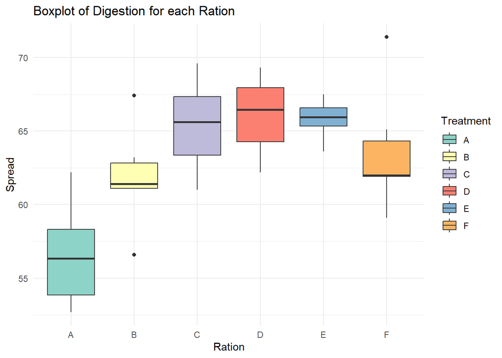

```r
ggplot(q2_data, aes(x = Treatment, y = Digestion, fill = Treatment))+
  geom_boxplot()+
  labs(
    title = "Boxplot of Digestion for each Ration",
    x = "Ration",
    y = "Spread"
  )+
  theme_minimal()+
  scale_fill_brewer(palette = "Set3")
```

## 3. Discuss the implications of your findings for nutritional strategies in cattle farming, highlighting any potential benefits or drawbacks of specific rations based on the digestibility results.

to achieve the most consistent results in steer digestion

when the rations **C, D** and **E** are not accessible **B and F** can be used as substitutes. Although they have some extreme values and medians around the first quartile, they do produce higher yields than the median nitrogen absorption for nitrogen intake of **A**.

**Avoid**

- Ration A should be avoided because it produces the lowest overall nitrogen digestion coefficients.
- However, if it is an essential ration it should be supplemented with one of the higher digestible **C, D** or **E** rations to try and offset its low coefficient of digestible nitrogen. The farmer is recommended not to substitute with **B** or **F** as it may lower the benefits of using them as rations leading to low yields.
- This is because of the low median yields for **B** and **F**

## A case of being curious

- Why does the other significant value have only one *
- Can this one * indicate that its hard to distinguish the groups ?

### Investigating which Field was different in Q1

```r
lsd_q1_field = LSD.test(aov(Yield~Fields, data = q1_data), "Field", p.adj = "none")
lsd_q1_field$groups
```

```
##   Yield groups
## 5 10.18      a
## 4  8.12      a
## 3  8.02      a
## 1  7.18      a
## 2  6.00      a
```

### Investigating which Period was different

```r
lsd_q2_opt = LSD.test(aov(Digestion~Period, data = q2_data), "Period", p.adj = "none")
lsd_q2_opt$groups
```

```
##   Digestion groups
## 1  65.06667      a
## 2  65.03333      a
## 5  64.30000      a
## 3  62.86667      a
## 4  61.76667      a
## 6  60.26667      a
```